# Practical Machine Learning - Exercise Analysis

## Executive Summary

This mini-project tested out three machine learning methods to see which had the most effective application to the problem of classifying a persons limb movement to a style of exercise performance. While all three showed capability of modelling the processes, the random forest method and boosting method should prove to be the most effective, although they are almost the most computationally resource draining which should be considered when designing a solution such as this.

## Introduction

To begin, the data was loaded and inspected for any unnecessary variables. Many columns were found to contain almost entirely NA values or had little to no variance throughout. These columns were detected via algorithm and removed from the training data as they are not useful for modeling purposes. Further, the columns pertaining to candidate information or dates and times were also removed as well.

```r
testing  <- read.csv("pml-testing.csv")
training <- read.csv("pml-training.csv")

rm_var <- which(sapply(training, function(x) mean(is.na(x)) > 0.95))
rm_var <- unique(c(1:5,rm_var,nearZeroVar(training)))

testing <- testing[-rm_var]
training <- training[-rm_var]
rm(rm_var)
```

```r
split  <- createDataPartition(training$classe, p=0.75, list=FALSE)
TrainData <- training[split, ]
TestData  <- training[-split, ]
```

## Training Models

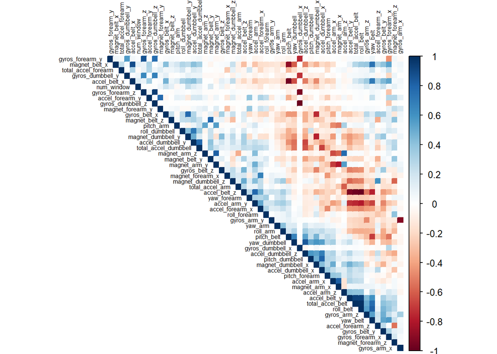

```r
cor_mat <- cor(TrainData[,-54])

corrplot(cor_mat, method = "color", type = "upper",
         insig = "label_sig", pch.col = "white", order = "AOE",
         tl.col = "black", tl.cex = 0.5)
```

Some variables are correlated with only a couple of others, albeit very strongly. Given that the target variable is qualitative while all the potential predictors are quantitative it seems appropriate to not remove any from the predictor pool.

### Decision Tree

[figure not shown]

```r
set.seed(12345)
decisionTreeMod <- rpart(classe ~ ., data=TrainData, method="class")
fancyRpartPlot(decisionTreeMod)
```

```r
predictTreeMod1 <- predict(decisionTreeMod, TestData, type = "class")
TestDataTree <- factor(TestData$classe,c("A","B","C","D","E"))
cmtree <- confusionMatrix(TestDataTree, predictTreeMod1)
cmtree
```

```
## Confusion Matrix and Statistics
##
##           Reference
## Prediction    A    B    C    D    E
##          A 1217   73    0   88   17
##          B   92  712   42   62   41
##          C    1   56  716   73    9
##          D   12   72   24  620   76
##          E    4   47    2   66  782
##
## Overall Statistics
##
##                Accuracy : 0.8252
##                  95% CI : (0.8143, 0.8358)
##     No Information Rate : 0.2704
##     P-Value [Acc > NIR] : < 2.2e-16
##
##                   Kappa : 0.7794
##
##  Mcnemar's Test P-Value : < 2.2e-16
##
## Statistics by Class:
##
##                      Class: A Class: B Class: C Class: D Class: E
## Sensitivity            0.9178   0.7417   0.9133   0.6821   0.8454
## Specificity            0.9503   0.9399   0.9663   0.9539   0.9701
## Pos Pred Value         0.8724   0.7503   0.8374   0.7711   0.8679
## Neg Pred Value         0.9689   0.9373   0.9832   0.9295   0.9643
## Prevalence             0.2704   0.1958   0.1599   0.1854   0.1886
## Detection Rate         0.2482   0.1452   0.1460   0.1264   0.1595
## Detection Prevalence   0.2845   0.1935   0.1743   0.1639   0.1837
## Balanced Accuracy      0.9340   0.8408   0.9398   0.8180   0.9077
```

### Random Forest

```r
tC <- trainControl(method = "cv", number = 3, p = .9,returnResamp="all")
randForestMod <- train(classe ~ ., data=TrainData, method="rf",
                          trControl=tC)

predictRandForestMod <- predict(randForestMod, TestData, type = "raw")
cmRandForestMod <- confusionMatrix(TestDataTree, predictRandForestMod)

cmRandForestMod
```

```
## Confusion Matrix and Statistics
##
##           Reference
## Prediction    A    B    C    D    E
##          A 1395    0    0    0    0
##          B    1  948    0    0    0
##          C    0    2  852    1    0
##          D    0    0    0  803    1
##          E    0    0    0    1  900
##
## Overall Statistics
##
##                Accuracy : 0.9988
##                  95% CI : (0.9973, 0.9996)
##     No Information Rate : 0.2847
##     P-Value [Acc > NIR] : < 2.2e-16
##
##                   Kappa : 0.9985
##
##  Mcnemar's Test P-Value : NA
##
## Statistics by Class:
##
##                      Class: A Class: B Class: C Class: D Class: E
## Sensitivity            0.9993   0.9979   1.0000   0.9975   0.9989
## Specificity            1.0000   0.9997   0.9993   0.9998   0.9998
## Pos Pred Value         1.0000   0.9989   0.9965   0.9988   0.9989
## Neg Pred Value         0.9997   0.9995   1.0000   0.9995   0.9998
## Prevalence             0.2847   0.1937   0.1737   0.1642   0.1837
## Detection Rate         0.2845   0.1933   0.1737   0.1637   0.1835
## Detection Prevalence   0.2845   0.1935   0.1743   0.1639   0.1837
## Balanced Accuracy      0.9996   0.9988   0.9996   0.9986   0.9993
```

The random forest method achieved an extrremely high accuracy rating of 99.9%.

### Boosting

```r
boostMod  <- train(classe ~ ., data=TrainData, method = "gbm", trControl = tC, verbose = FALSE)

predictBoostMod <- predict(boostMod, TestData, type = "raw")


cmBoostMod <- confusionMatrix(TestDataTree, predictBoostMod)
cmBoostMod
```

```
## Confusion Matrix and Statistics
##
##           Reference
## Prediction    A    B    C    D    E
##          A 1388    7    0    0    0
##          B   10  932    7    0    0
##          C    0    9  839    5    2
##          D    0    4    7  791    2
##          E    0    4    1    3  893
##
## Overall Statistics
##
##                Accuracy : 0.9876
##                  95% CI : (0.9841, 0.9905)
##     No Information Rate : 0.2851
##     P-Value [Acc > NIR] : < 2.2e-16
##
##                   Kappa : 0.9843
##
##  Mcnemar's Test P-Value : NA
##
## Statistics by Class:
##
##                      Class: A Class: B Class: C Class: D Class: E
## Sensitivity            0.9928   0.9749   0.9824   0.9900   0.9955
## Specificity            0.9980   0.9957   0.9960   0.9968   0.9980
## Pos Pred Value         0.9950   0.9821   0.9813   0.9838   0.9911
## Neg Pred Value         0.9972   0.9939   0.9963   0.9980   0.9990
## Prevalence             0.2851   0.1949   0.1741   0.1629   0.1829
## Detection Rate         0.2830   0.1900   0.1711   0.1613   0.1821
## Detection Prevalence   0.2845   0.1935   0.1743   0.1639   0.1837
## Balanced Accuracy      0.9954   0.9853   0.9892   0.9934   0.9968
```